# Heritability analysis update

E Schlatter

7/7/2022

## Estimates using updated priors

Following the suggestion of one reviewer, I’ve changed the priors a bit. We’re estimating three variance components: additive genetic, clutch, and residual. (Or five – add dam and sire – in the model with parental effects.) Previously I’d used priors that were very flat, but with their mode close to zero. The reviewer suggested trying modes equal to 1/3 (or 1/5) of the phenotypic variance. In words, I think this means our null hypothesis is that all components contribute equally to the phenotypic variance, rather than that all components contribute nothing. That makes me realize that a more appropriate choice of prior than our original one would be to have the modes close to zero for all components except the residual variance, which should have a mode equal to the observed phenotypic variance. That corresponds to the null hypothesis that all variation is residual – i.e., none of it can be accounted for by our predictor variables.

[try clutch and animal = 0, residual = p_var]

## Prior sensitivity

### Ucrit, no parents

First, generate the model runs.

Total phenotypic variance in Ucrit is 4.58. We’re estimating three components of variance: VA, VC, and VE. Each run will use a different set of prior distributions for VA, VC, and VE. All priors will be inverse gamma with nu = 0.001 (i.e., very flat), so they can be uniquely defined by the mode (peak).

- We’ll keep the mode of the prior for VC the same for all runs: 0.65. (This is a good guess for the actual value, based on previous tries.)
- For each run, choose the prior mode of VA from a sequence running from 0 to the total phenotypic variance (minus the VC mode).
- Then define the prior mode of VE so that the three prior modes add up to the total phenotypic variance.

E.g., run 1: VC mode = 0.65. VA mode = 0.05. So VE mode = 4.58 - 0.65 - 0.05 = 3.88.

```r
p_var = var(phens$speed,na.rm=TRUE) #test (phenotypic variance)
prior_modes = p_var*c(0.01,seq(0.05,1,by=0.05)) # test a range of modes from 1% to 100% of the phenotypic variance
nu = 0.001

#set prior mode for clutch at reasonable estimate of 0.65; stays the same for all of these model runs
p_C = 0.65
V_C = ((nu+2)/nu)*0.65

# Run model for range of priors and store results
VA_samples = data.frame(matrix(ncol=10,nrow=0))
VC_samples = data.frame(matrix(ncol=10,nrow=0))
VE_samples = data.frame(matrix(ncol=10,nrow=0))

for(p in prior_modes){
  V_A = ((nu+2)/nu)*p
  p_E = p_var - p - p_C
  V_E = ((nu+2)/nu)*p_E

  prior = list(R=list(V=V_E,nu=0.001),G=list(G1=list(V=V_A,nu=0.001),G2=list(V=V_C,nu=0.001)))
  model <- MCMCglmm(speed~1+age,
                    random=~animal+clutch,
                    prior=prior, ginverse=list(animal=Ainv),
                    data=phens,nitt=100000,burnin=round(.01*100000),thin=10,verbose=FALSE)
  v_mcmc <- model$VCV
  effSamp=effectiveSize(v_mcmc)

  #VA
  animal_samples = as.data.frame(model$VCV)$animal
  quants = quantile(animal_samples,c(0.05,0.25,0.5,0.75,0.95))
  post_density = density(animal_samples)
  post_mode = post_density$x[which.max(post_density$y)]
  effSampA = as.data.frame(t(effSamp))$animal
  newrow=c(p,p_E,p_C,effSampA,post_mode,as.numeric(quants))
  VA_samples = rbind(VA_samples,newrow)

  #VC
  clutch_samples = as.data.frame(model$VCV)$clutch
  quants = quantile(clutch_samples,c(0.05,0.25,0.5,0.75,0.95))
  post_density = density(clutch_samples)
  post_mode = post_density$x[which.max(post_density$y)]
  effSampC = as.data.frame(t(effSamp))$clutch
  newrow=c(p,p_E,p_C,effSampC,post_mode,as.numeric(quants))
  VC_samples = rbind(VC_samples,newrow)

  #VE
  units_samples = as.data.frame(model$VCV)$units
  quants = quantile(units_samples,c(0.05,0.25,0.5,0.75,0.95))
  post_density = density(units_samples)
  post_mode = post_density$x[which.max(post_density$y)]
  effSampE = as.data.frame(t(effSamp))$units
  newrow=c(p,p_E,p_C,effSampE,post_mode,as.numeric(quants))
  VE_samples = rbind(VE_samples,newrow)

  #save model run for further use
  save(model,file=paste0('../model_runs/prior_sensitivity/Again/Ucrit_noparent_p=',round(p,3),'.RData'))
  print(p)
}

colnames(VA_samples)=c('prior_mode_A','prior_mode_E','prior_mode_C','effSampVA','post_mode','q5','q25','q50','q75','q95')
colnames(VC_samples)=c('prior_mode_A','prior_mode_E','prior_mode_C','effSampVC','post_mode','q5','q25','q50','q75','q95')
colnames(VE_samples)=c('prior_mode_A','prior_mode_E','prior_mode_C','effSampVE','post_mode','q5','q25','q50','q75','q95')

save(VA_samples,file='../model_runs/prior_sensitivity/Again/Ucrit_noparent_VA.RData')
save(VC_samples,file='../model_runs/prior_sensitivity/Again/Ucrit_noparent_VC.RData')
save(VE_samples,file='../model_runs/prior_sensitivity/Again/Ucrit_noparent_VE.RData')
```

Plot priors vs posteriors. Black points (modes) and intervals (5%-95% regions) are posterior estimates of VA, with prior mode indicated by x-axis value. Blue points (modes) and intervals (5%-95% regions) are posterior estimates of VE, with prior mode chosen so the prior modes of VA, VE, and VC add up to the total phenotypic variance. Black diagonal line is 1-1. Purple vertical line is the prior value we actually used. Red line is (scaled) effective sample size for VA (an indication of how well the MCMC algorithm worked).

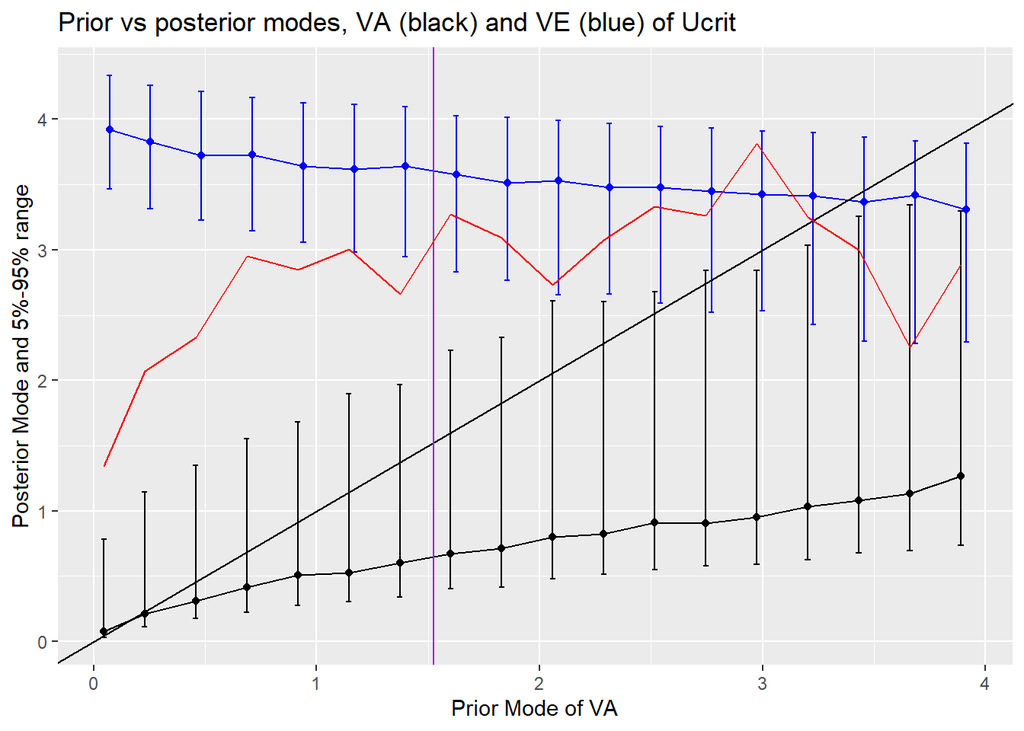

```r
p_var = var(phens$speed,na.rm=TRUE) #test (phenotypic variance)
prior_modes = p_var*c(0.01,seq(0.05,1,by=0.05)) # test a range of modes from 1% to 100% of the phenotypic variance
nu = 0.001

load(file='../model_runs/prior_sensitivity/Again/Ucrit_noparent_VA.RData')
load(file='../model_runs/prior_sensitivity/Again/Ucrit_noparent_VC.RData')
load(file='../model_runs/prior_sensitivity/Again/Ucrit_noparent_VE.RData')

ggplot(data=VA_samples,aes(x=prior_mode_A,y=post_mode))+
  geom_point()+
  geom_line()+
  xlab('Prior Mode of VA')+
  ylab('Posterior Mode and 5%-95% range')+
  ggtitle('Prior vs posterior modes, VA (black) and VE (blue) of Ucrit')+
  geom_errorbar(aes(ymin=q5, ymax=q95),width=0.025)+
  geom_point(data=VE_samples,aes(x=prior_mode_A+.025,y=post_mode),color='blue')+
  geom_line(data=VE_samples,aes(x=prior_mode_A+.025,y=post_mode),color='blue')+
  geom_errorbar(data=VE_samples,aes(x=prior_mode_A+.025,ymin=q5, ymax=q95),color='blue',width=0.025)+
  geom_abline(slope=1,intercept=0)+
  geom_vline(xintercept=p_var/3,color='purple')+
  geom_line(data=VA_samples,aes(x=prior_mode_A,y=effSampVA*(4/700)),color='red')
```

Plot example priors and posteriors for a single run

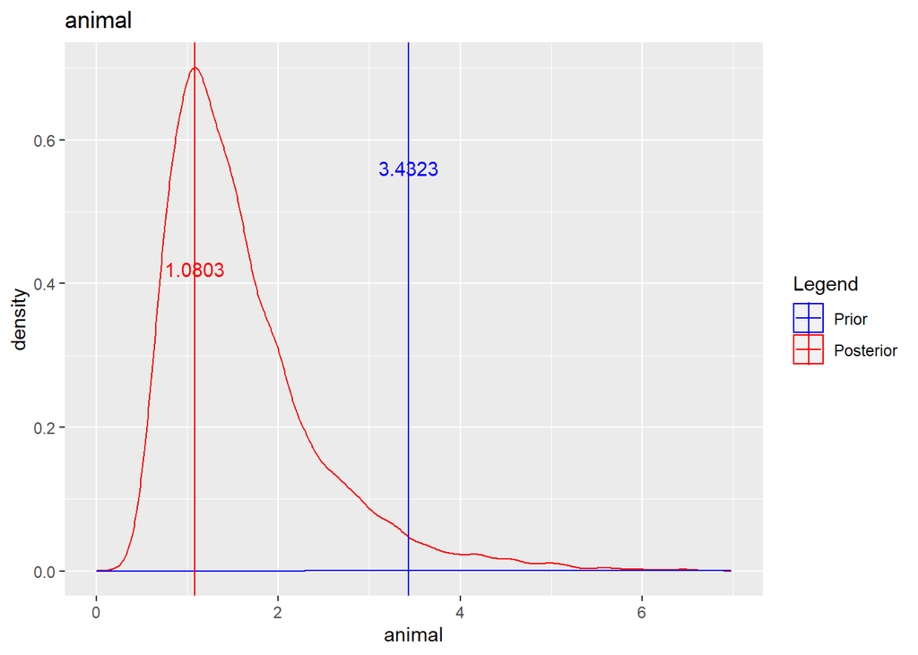

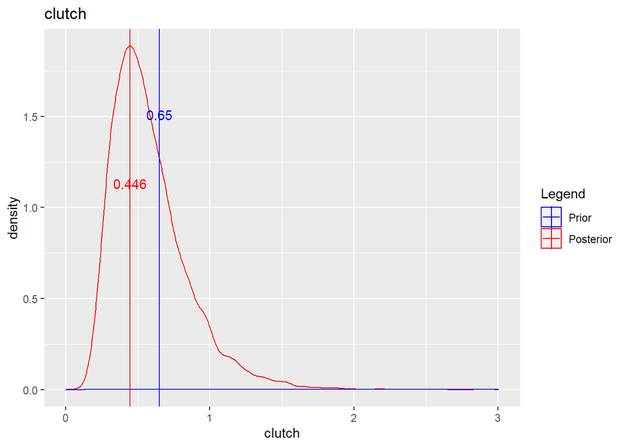

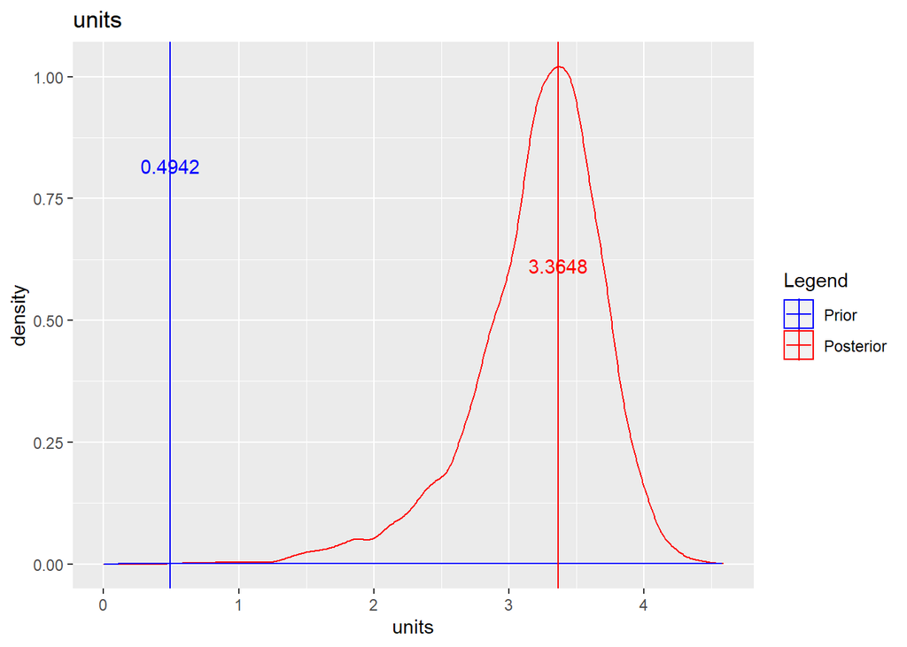

```r
load(file='../model_runs/prior_sensitivity/Again/Ucrit_noparent_VA.RData')
load(file='../model_runs/prior_sensitivity/Again/Ucrit_noparent_VC.RData')
load(file='../model_runs/prior_sensitivity/Again/Ucrit_noparent_VE.RData')


i = 16 #plot the model in the ith row of the samples tables

load(file=paste0('../model_runs/prior_sensitivity/Again/Ucrit_noparent_p=',round(prior_modes[i],3),'.RData'))
V_A = VA_samples$prior_mode_A[i]*(nu+2)/nu
V_C = VA_samples$prior_mode_C[i]*(nu+2)/nu
V_E = VA_samples$prior_mode_E[i]*(nu+2)/nu
plot_priorandpost_new(model,nu.=nu,V_A=V_A,V_C=V_C,V_E=V_E,xlim=p_var)
```

### Ucrit, with parents

Total phenotypic variance in Ucrit is 4.58. We’re estimating five components of variance: VA, VC, VD, VS, and VE. Each run will use a different set of prior distributions for the variance components. All priors will be inverse gamma with nu = 0.001 (i.e., very flat), so they can be uniquely defined by the mode (peak).

- We’ll keep the mode of the prior for VC the same for all runs: 0.65. (This is a good guess for the actual value, based on previous tries.)
- Set VD and VS prior modes to 0.65 also. This is probably a little high.
- For each run, choose the prior mode of VA from a sequence running from 0 to the total phenotypic variance (minus the VC, VD, and VS modes).
- Then define the prior mode of VE so that the five prior modes add up to the total phenotypic variance.

[Checked with other values for VC, VD, and VS prior modes: all 0.25 or all 1. Increasing prior mode increases estimate of each of these variance components, which decreases estimate of VA and doesn’t affect estimate of VE. This is pretty much what we’d expect.] Second run: same thing, but VC, VD and VS prior modes are all 0.25. Third run: same thing, but VC, VD and VS prior modes are all 1.

Plot priors vs posteriors. Black points (modes) and intervals (5%-95% regions) are posterior estimates of VA, with prior mode indicated by x-axis value. Blue points (modes) and intervals (5%-95% regions) are posterior estimates of VE, with prior mode chosen so the prior modes of VA, VE, and VC add up to the total phenotypic variance. Black diagonal line is 1-1. Purple vertical line is the prior value we actually used. Red line is (scaled) effective sample size for VA (an indication of how well the MCMC algorithm worked).

[figure not shown]

```r
load(file='../model_runs/prior_sensitivity/Again/Ucrit_withparent_VA.RData')
load(file='../model_runs/prior_sensitivity/Again/Ucrit_withparent_VC.RData')
load(file='../model_runs/prior_sensitivity/Again/Ucrit_withparent_VD.RData')
load(file='../model_runs/prior_sensitivity/Again/Ucrit_withparent_VS.RData')
load(file='../model_runs/prior_sensitivity/Again/Ucrit_withparent_VE.RData')


i = 16 #plot the model in the ith row of the samples tables

load(file=paste0('../model_runs/prior_sensitivity/Again/Ucrit_noparent_p=',round(prior_modes[i],3),'.RData'))
V_A = VA_samples$prior_mode_A[i]*(nu+2)/nu
V_C = VA_samples$prior_mode_C[i]*(nu+2)/nu
V_E = VA_samples$prior_mode_E[i]*(nu+2)/nu
plot_priorandpost_new(model,nu.=nu,V_A=V_A,V_C=V_C,V_E=V_E,xlim=p_var)
```

[output not shown]

### SL, no parents

First, generate the model runs.

Total phenotypic variance in SL is 0.015. We’re estimating three components of variance: VA, VC, and VE. Each run will use a different set of prior distributions for VA, VC, and VE. All priors will be inverse gamma with nu = 0.001 (i.e., very flat), so they can be uniquely defined by the mode (peak).

- We’ll keep the mode of the prior for VC the same for all runs: 0.0025. (This is a good guess for the actual value, based on previous tries.)
- For each run, choose the prior mode of VA from a sequence running from 0 to the total phenotypic variance (minus the VC mode).
- Then define the prior mode of VE so that the three prior modes add up to the total phenotypic variance.

```r
p_var = var(phens$length,na.rm=TRUE) #test (phenotypic variance)
prior_modes = p_var*c(0.01,seq(0.05,1,by=0.05)) # test a range of modes from 1% to 100% of the phenotypic variance
nu = 0.001

#set prior mode for clutch at reasonable estimate of 0.65; stays the same for all of these model runs
p_C = 0.0025
V_C = ((nu+2)/nu)*0.0025

# Run model for range of priors and store results
VA_samples = data.frame(matrix(ncol=10,nrow=0))
VC_samples = data.frame(matrix(ncol=10,nrow=0))
VE_samples = data.frame(matrix(ncol=10,nrow=0))

for(p in prior_modes){
  V_A = ((nu+2)/nu)*p
  p_E = p_var - p - p_C
  V_E = ((nu+2)/nu)*p_E

  prior = list(R=list(V=V_E,nu=0.001),G=list(G1=list(V=V_A,nu=0.001),G2=list(V=V_C,nu=0.001)))
  model <- MCMCglmm(length~1+age,
                    random=~animal+clutch,
                    prior=prior, ginverse=list(animal=Ainv),
                    data=phens,nitt=100000,burnin=round(.01*100000),thin=10,verbose=FALSE)
  v_mcmc <- model$VCV
  effSamp=effectiveSize(v_mcmc)

  #VA
  animal_samples = as.data.frame(model$VCV)$animal
  quants = quantile(animal_samples,c(0.05,0.25,0.5,0.75,0.95))
  post_density = density(animal_samples)
  post_mode = post_density$x[which.max(post_density$y)]
  effSampA = as.data.frame(t(effSamp))$animal
  newrow=c(p,p_E,p_C,effSampA,post_mode,as.numeric(quants))
  VA_samples = rbind(VA_samples,newrow)

  #VC
  clutch_samples = as.data.frame(model$VCV)$clutch
  quants = quantile(clutch_samples,c(0.05,0.25,0.5,0.75,0.95))
  post_density = density(clutch_samples)
  post_mode = post_density$x[which.max(post_density$y)]
  effSampC = as.data.frame(t(effSamp))$clutch
  newrow=c(p,p_E,p_C,effSampC,post_mode,as.numeric(quants))
  VC_samples = rbind(VC_samples,newrow)

  #VE
  units_samples = as.data.frame(model$VCV)$units
  quants = quantile(units_samples,c(0.05,0.25,0.5,0.75,0.95))
  post_density = density(units_samples)
  post_mode = post_density$x[which.max(post_density$y)]
  effSampE = as.data.frame(t(effSamp))$units
  newrow=c(p,p_E,p_C,effSampE,post_mode,as.numeric(quants))
  VE_samples = rbind(VE_samples,newrow)

  #save model run for further use
  save(model,file=paste0('../model_runs/prior_sensitivity/Again/SL_noparent_p=',round(p,3),'.RData'))
  print(p)
}

colnames(VA_samples)=c('prior_mode_A','prior_mode_E','prior_mode_C','effSampVA','post_mode','q5','q25','q50','q75','q95')
colnames(VC_samples)=c('prior_mode_A','prior_mode_E','prior_mode_C','effSampVC','post_mode','q5','q25','q50','q75','q95')
colnames(VE_samples)=c('prior_mode_A','prior_mode_E','prior_mode_C','effSampVE','post_mode','q5','q25','q50','q75','q95')

save(VA_samples,file='../model_runs/prior_sensitivity/Again/SL_noparent_VA.RData')
save(VC_samples,file='../model_runs/prior_sensitivity/Again/SL_noparent_VC.RData')
save(VE_samples,file='../model_runs/prior_sensitivity/Again/SL_noparent_VE.RData')
```

Plot priors vs posteriors. Black points (modes) and intervals (5%-95% regions) are posterior estimates of VA, with prior mode indicated by x-axis value. Blue points (modes) and intervals (5%-95% regions) are posterior estimates of VE, with prior mode chosen so the prior modes of VA, VE, and VC add up to the total phenotypic variance. Black diagonal line is 1-1. Purple vertical line is the prior value we actually used. Red line is (scaled) effective sample size for VA (an indication of how well the MCMC algorithm worked).

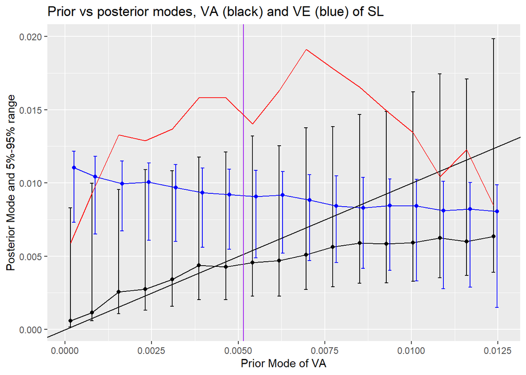

```r
p_var = var(phens$length,na.rm=TRUE) #test (phenotypic variance)
prior_modes = p_var*c(0.01,seq(0.05,1,by=0.05)) # test a range of modes from 1% to 100% of the phenotypic variance
nu = 0.001

load(file='../model_runs/prior_sensitivity/Again/SL_noparent_VA.RData')
load(file='../model_runs/prior_sensitivity/Again/SL_noparent_VC.RData')
load(file='../model_runs/prior_sensitivity/Again/SL_noparent_VE.RData')

ggplot(data=VA_samples,aes(x=prior_mode_A,y=post_mode))+
  geom_point()+
  geom_line()+
  xlab('Prior Mode of VA')+
  ylab('Posterior Mode and 5%-95% range')+
  ggtitle('Prior vs posterior modes, VA (black) and VE (blue) of SL')+
  geom_errorbar(aes(ymin=q5, ymax=q95),width=0.0001)+
  geom_point(data=VE_samples,aes(x=prior_mode_A+.0001,y=post_mode),color='blue')+
  geom_line(data=VE_samples,aes(x=prior_mode_A+.0001,y=post_mode),color='blue')+
  geom_errorbar(data=VE_samples,aes(x=prior_mode_A+.0001,ymin=q5, ymax=q95),color='blue',width=0.0001)+
  geom_abline(slope=1,intercept=0)+
  geom_vline(xintercept=p_var/3,color='purple')+
  geom_line(data=VA_samples,aes(x=prior_mode_A,y=effSampVA*(0.02/600)),color='red')
```

Plot example priors and posteriors for a single run

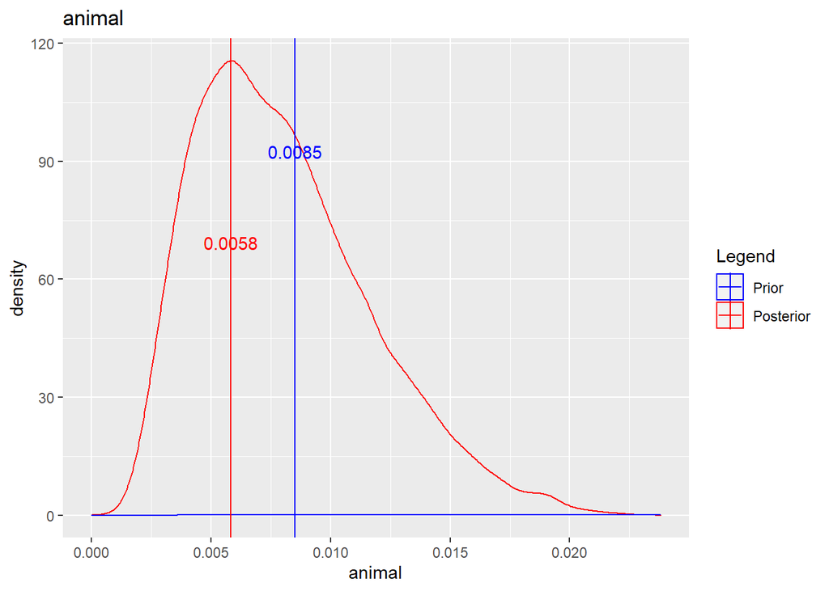

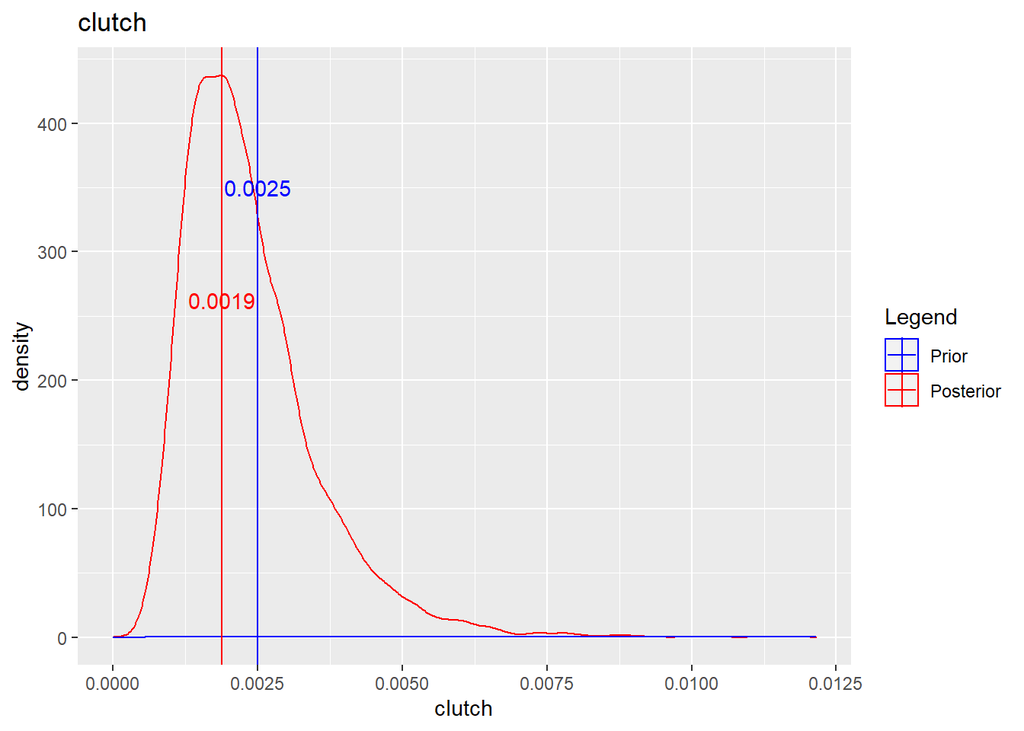

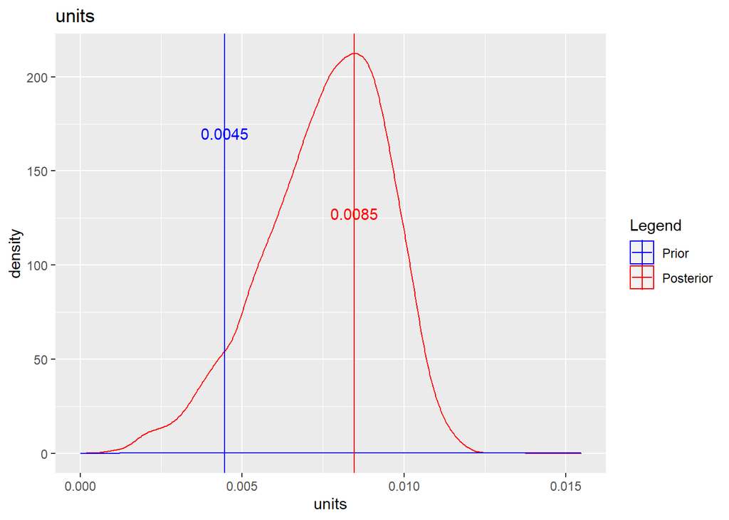

```r
load(file='../model_runs/prior_sensitivity/Again/SL_noparent_VA.RData')
load(file='../model_runs/prior_sensitivity/Again/SL_noparent_VC.RData')
load(file='../model_runs/prior_sensitivity/Again/SL_noparent_VE.RData')


i = 12 #plot the model in the ith row of the samples tables

load(file=paste0('../model_runs/prior_sensitivity/Again/SL_noparent_p=',round(prior_modes[i],3),'.RData'))
V_A = VA_samples$prior_mode_A[i]*(nu+2)/nu
V_C = VA_samples$prior_mode_C[i]*(nu+2)/nu
V_E = VA_samples$prior_mode_E[i]*(nu+2)/nu
plot_priorandpost_new(model,nu.=nu,V_A=V_A,V_C=V_C,V_E=V_E,xlim=p_var)
```

### SL, with parents

Plot priors vs posteriors. Black points (modes) and intervals (5%-95% regions) are posterior estimates of VA, with prior mode indicated by x-axis value. Blue points (modes) and intervals (5%-95% regions) are posterior estimates of VE, with prior mode chosen so the prior modes of VA, VE, and VC add up to the total phenotypic variance. Black diagonal line is 1-1. Purple vertical line is the prior value we actually used. Red line is (scaled) effective sample size for VA (an indication of how well the MCMC algorithm worked).

[3rd run: same priors for VC, VD, VS each time; chosen based on means in manuscript.]

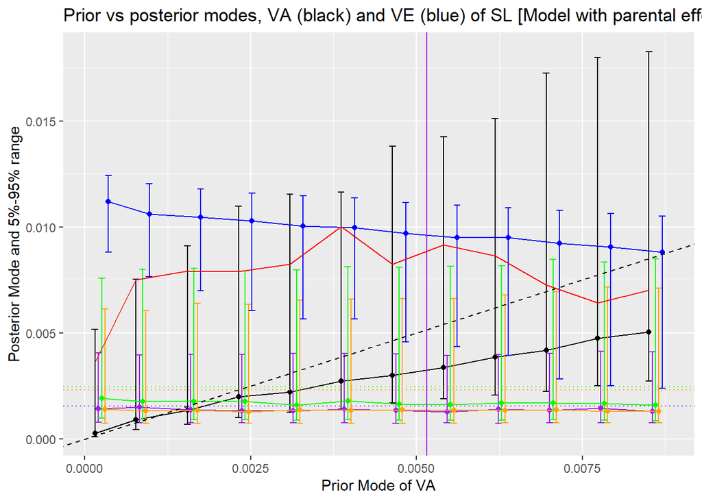